# Populus tri photosynthesis phenotype exploration

The duplicate analysis needs to be more complete…

```r
dat1<-read.csv("datainput_2_27_2015.csv")
head(dat1)
names(dat1)

dat1$id<-toupper(dat1$id) #all letters upper case
dat1$id<-gsub("*.CSV", "", dat1$id) # replace .csv to blank
head(dat1)
str(dat1)
```

[output not shown]

Histograms of phenotype/trait/madel parameter distributions:

[output not shown]

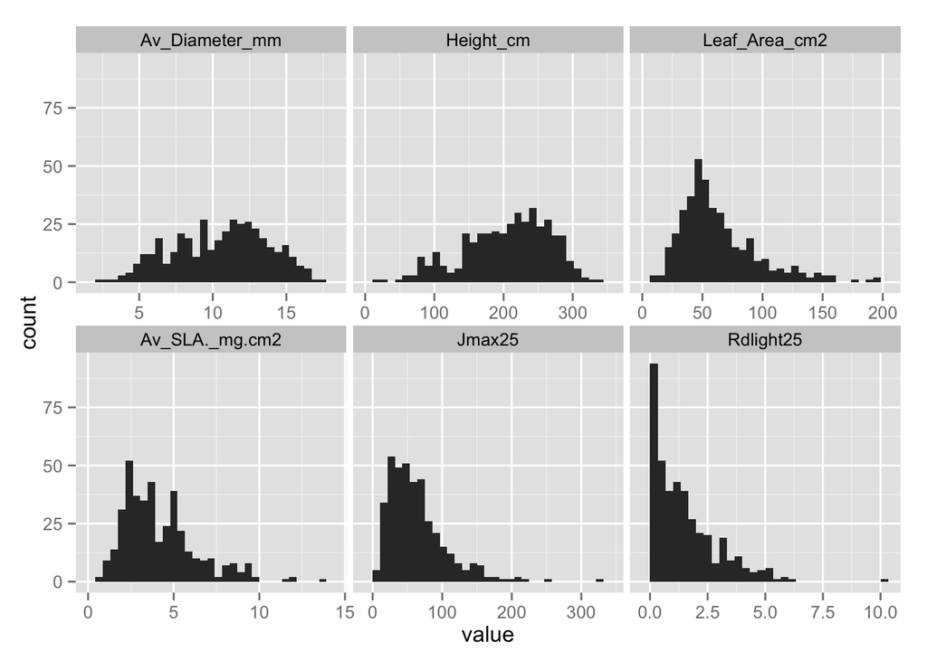

Same, but with data filtered Asat < 40 (this excludes 7 observations)

[output not shown]

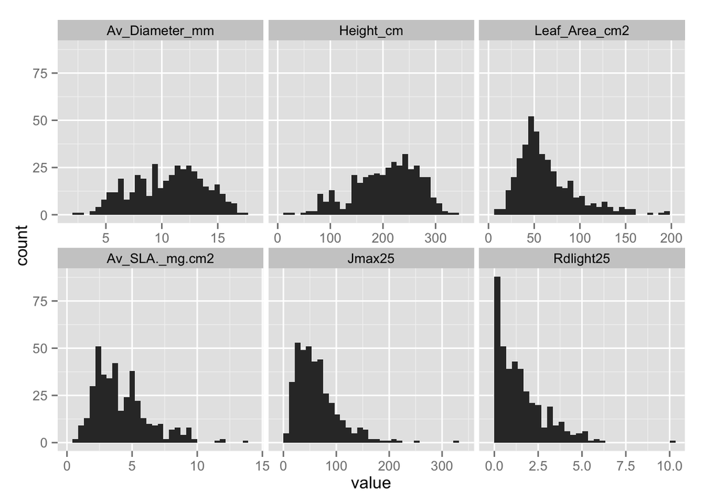

Histograms of phenotype/trait/madel parameter distributions:

[output not shown]

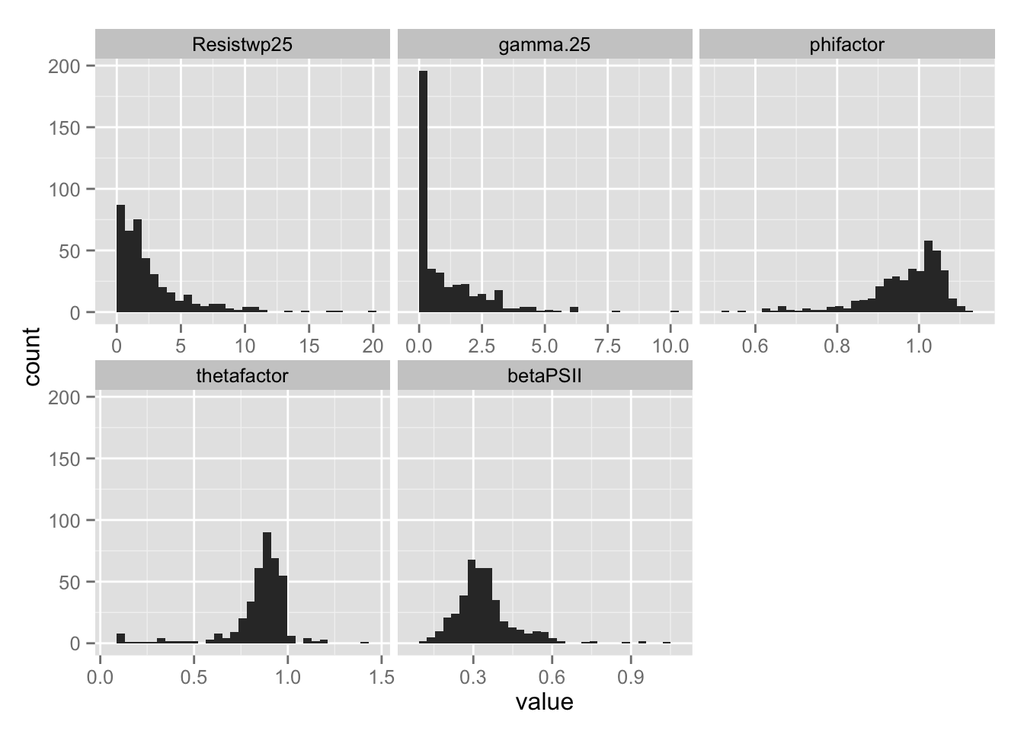

Same, but with data filtered Asat < 40 (this excludes 7 observations)

[output not shown]

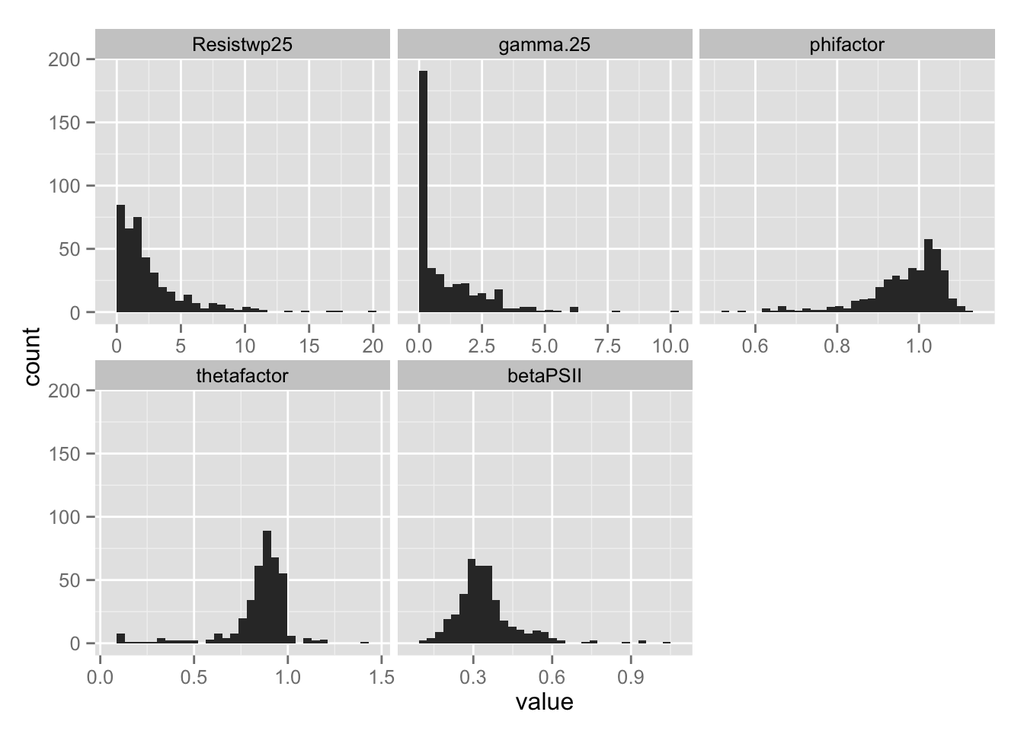

Histograms of phenotype/trait/madel parameter distributions:

[output not shown]

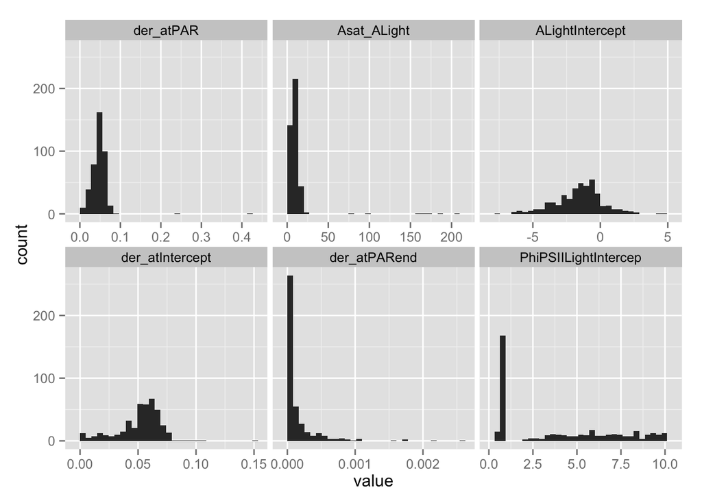

Same, but with data filtered Asat < 40 (this excludes 7 observations)

[output not shown]

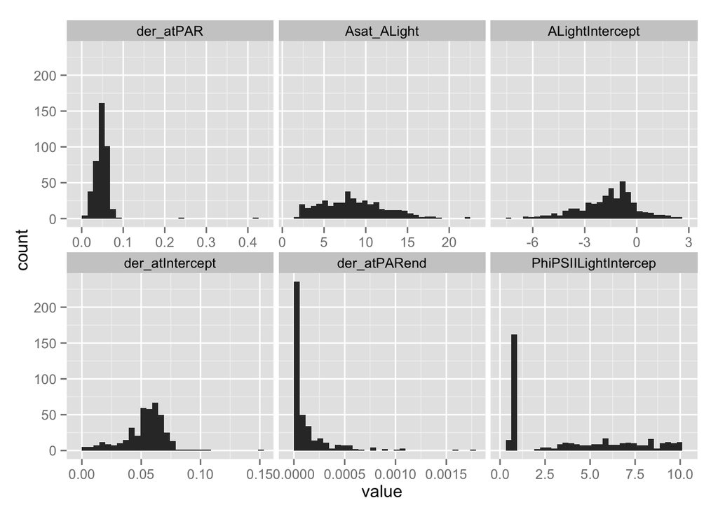

Histograms of phenotype/trait/madel parameter distributions:

```
## Using  as id variables
## stat_bin: binwidth defaulted to range/30. Use 'binwidth = x' to adjust this.
## stat_bin: binwidth defaulted to range/30. Use 'binwidth = x' to adjust this.
```

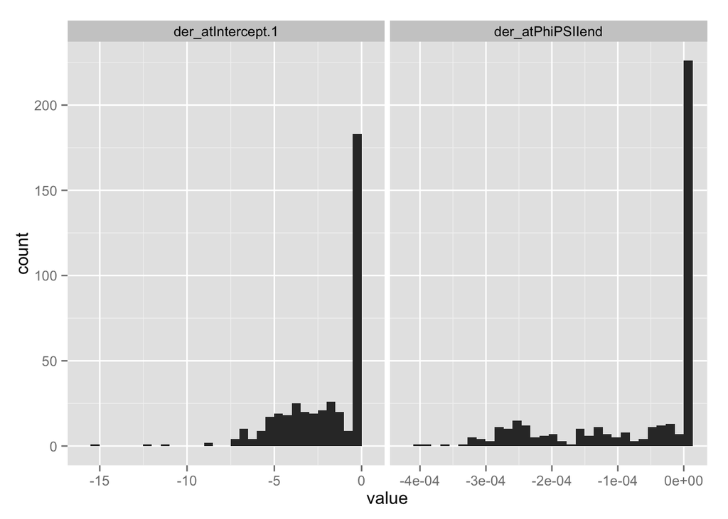

Same, but with data filtered Asat < 40 (this excludes 7 observations)

```
## Using  as id variables
## stat_bin: binwidth defaulted to range/30. Use 'binwidth = x' to adjust this.
## stat_bin: binwidth defaulted to range/30. Use 'binwidth = x' to adjust this.
```

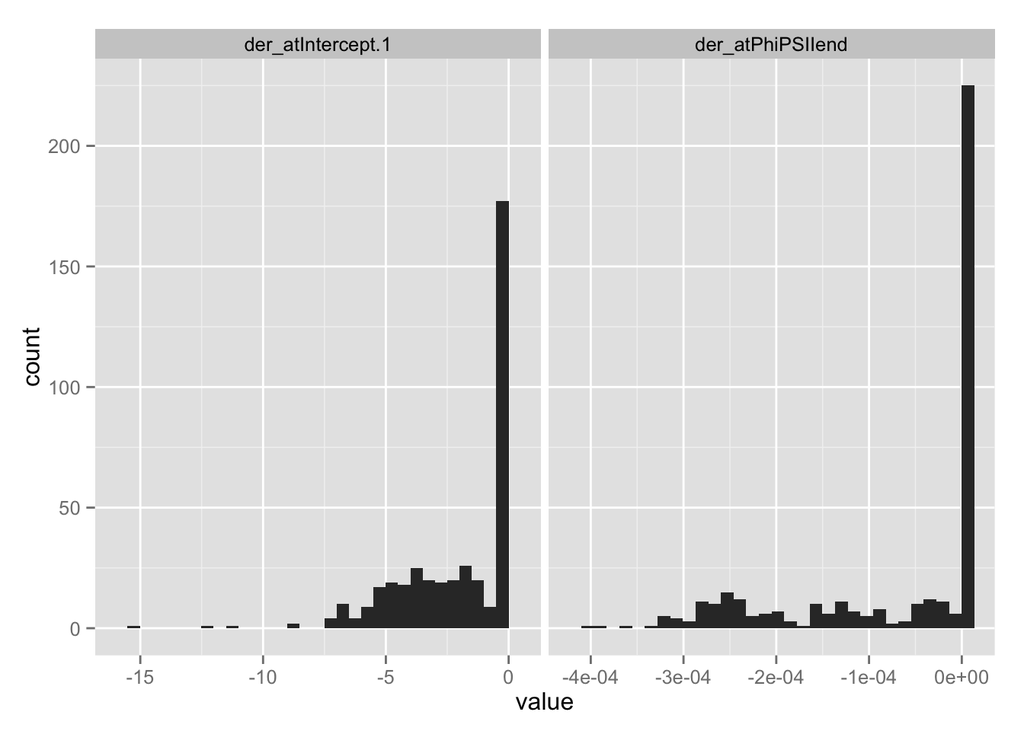

now phenotype correlations between all variables

```r
library(dplyr)
d<-dat1%>%
    select(diam = Av_Diameter_mm, LA=Leaf_Area_cm2, height = Height_cm, SLA = Av_SLA._mg.cm2, Asat = Asat_ALight, Jmax = Jmax25, PSII_effic = PhiPSIIsat_ALight, PSII_dark_effic = PhiPSIILightIntercep, PSI_PSII = betaPSII, CO2_comp = gamma.25, day_resp = Rdlight25, GmRwp = Resistwp25, GmRcp = Resistch25) %>%
    filter(Asat < 40)

cor(d, use="complete.obs")
```

[output not shown]

*Corrlegrams*

Paramters for the correlagrams:

order=TRUE will cause the variables to be ordered using principal component analysis of the correlation matrix.

panel.pie (the filled portion of the pie indicates the magnitude of the correlation)

panel.shade (the depth of the shading indicates the magnitude of the correlation)

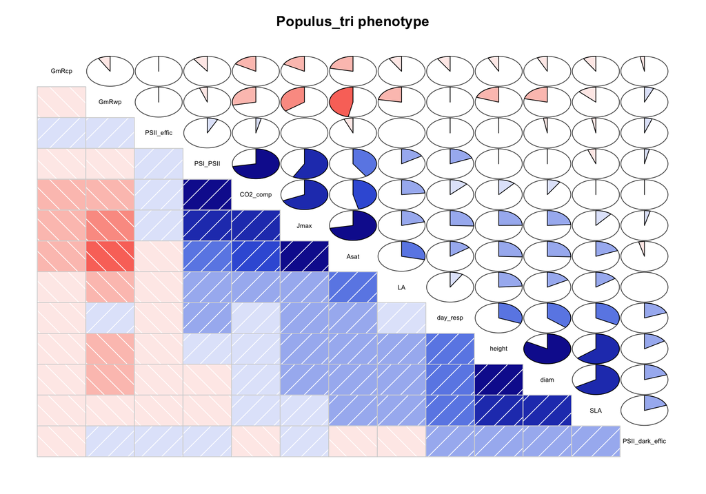

```r
library(corrgram)
corrgram(d, order=TRUE, lower.panel=panel.shade,
  upper.panel=panel.pie, text.panel=panel.txt,
  main="Populus_tri phenotype")
```

Corrlegram with dotplots

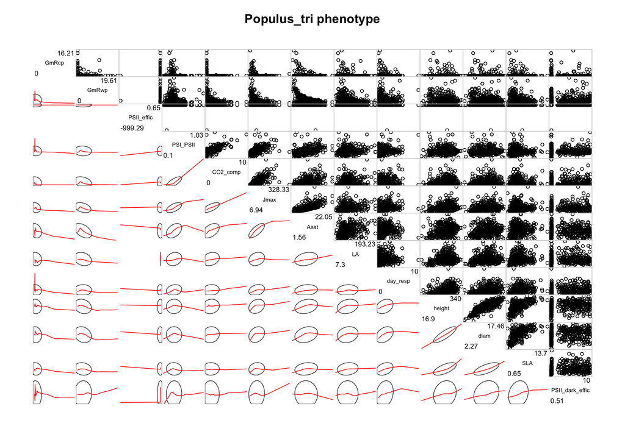

```r
corrgram(d, order=TRUE, lower.panel=panel.ellipse,
  upper.panel=panel.pts, text.panel=panel.txt,
  diag.panel=panel.minmax,
  main="Populus_tri phenotype")
```

Calculate ‘genetic variation,’ from Junfei Gu et al. Plant, Cell and Environment (2014) 37, 22–34; which is really phenotypic varaition. According to the authors, genetic variation was calculated as (Xmax − Xmin )/Xmean, where Xmax and Xmin stands for maximum and minimum value in the population, respectively.

| diam | LA | height | SLA | Asat | Jmax | PSII_effic |
| --- | --- | --- | --- | --- | --- | --- |
| 1.44 | 2.92 | 1.57 | 3.12 | 2.39 | 5.02 | -436.59 |

| PSII_dark_effic | PSI_PSII | CO2_comp | day_resp | GmRwp | GmRcp | Asat |
| --- | --- | --- | --- | --- | --- | --- |
| 2.41 | 2.68 | 9.52 | 6.64 | 7.6 | 43.72 | 2.39 |

```
##
##
## Guessing width = 0.5 # range / 40
```

```
## Guessing width = 0.5 # range / 33
```

Heat maps for each trait vaition for each individual: calculated as in Junfei Gu et al PC&E 2014. Where (Xi - Xmean)/Xmean, where Xi is the ith genotype and Xmean is the population mean.

| diam | LA | height | SLA | Asat | Jmax | PSII_effic | PSII_dark_effic | PSI_PSII | CO2_comp | day_resp | GmRwp | GmRcp |
| --- | --- | --- | --- | --- | --- | --- | --- | --- | --- | --- | --- | --- |
| 10.56 | 63.22 | 205.9 | 4.19 | 8.51 | 62.26 | -2.34 | 3.9 | 0.34 | 0.96 | 1.47 | 2.61 | 0.38 |

Trait clustering and heat map of the 400 individuals. Each rectangle represents (Xi - Xmean)/Xmean from Junfei Gu et al PC&E 2014, which is an estimate of the phenotypic variation for that trait.

NAs were transformed to 0, which is the mean value for (Xi - Xmean)/Xmean.

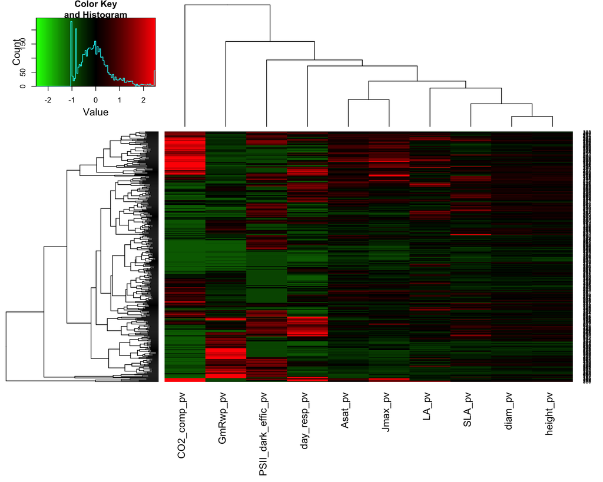